# Student Academic Performance Analysis Using R

MIN KHANT KO

2026-09-22

# 1. Introduction

Student academic performance can be studied using marks, attendance, gender, and examination results. This Tiny Project uses R and R Markdown to import, clean, analyze, visualize, and interpret student data.

## 2. Objectives

The objectives of this project are:

- To import student data from a CSV file.
- To inspect and clean the dataset.
- To calculate descriptive statistics for student marks.
- To examine gender and pass/fail distributions.
- To visualize marks and attendance.
- To study the relationship between attendance and marks.
- To summarize the main findings.

# 3. Required Packages

The analysis uses base R functions, so no additional packages are required.

# 4. Data Importing

The dataset is stored in a CSV file. The `read.csv()` function imports the data into R.

```r
student_data <- read.csv("student_data.csv",
                         stringsAsFactors = FALSE)

student_data
```

```
##     Name Gender Attendance Marks Result
## 1   Aung   Male         92    88   Pass
## 2    Min   Male         85    76   Pass
## 3  Thiri Female         95    91   Pass
## 4     Su Female         78    64   Pass
## 5   Htet   Male         72    55   Pass
## 6    May Female         88    82   Pass
## 7     Ko   Male         65    48   Fail
## 8     Ei Female         90    86   Pass
## 9    Lin   Male         80    70   Pass
## 10   Mya Female         68    52   Fail
## 11 Nyein   Male         94    89   Pass
## 12   Hla Female         75    61   Pass
## 13   Zaw   Male         60    45   Fail
## 14  Khin Female         97    94   Pass
## 15   Tun   Male         83    73   Pass
```

The dataset contains student names, gender, attendance percentage, marks, and examination result.

# 5. Data Exploration

## First few observations

`head()` displays the first six rows of the dataset.

```r
head(student_data)
```

```
##    Name Gender Attendance Marks Result
## 1  Aung   Male         92    88   Pass
## 2   Min   Male         85    76   Pass
## 3 Thiri Female         95    91   Pass
## 4    Su Female         78    64   Pass
## 5  Htet   Male         72    55   Pass
## 6   May Female         88    82   Pass
```

## Structure of the data

`str()` shows the variables, their data types, and the structure of the dataset.

```r
str(student_data)
```

```
## 'data.frame':    15 obs. of  5 variables:
##  $ Name      : chr  "Aung" "Min" "Thiri" "Su" ...
##  $ Gender    : chr  " Male" " Male" "Female" "Female" ...
##  $ Attendance: int  92 85 95 78 72 88 65 90 80 68 ...
##  $ Marks     : int  88 76 91 64 55 82 48 86 70 52 ...
##  $ Result    : chr  "Pass" "Pass" "Pass" "Pass" ...
```

## Summary statistics

`summary()` provides a quick statistical summary of the numerical and categorical variables.

```r
summary(student_data)
```

```
##         Name          Gender     Attendance        Marks            Result
##  Length   :15   Length   :15   Min.   :60.00   Min.   :45.0   Length   :15
##  N.unique :15   N.unique : 3   1st Qu.:73.50   1st Qu.:58.0   N.unique : 2
##  N.blank  : 0   N.blank  : 0   Median :83.00   Median :73.0   N.blank  : 0
##  Min.nchar: 2   Min.nchar: 4   Mean   :81.47   Mean   :71.6   Min.nchar: 4
##  Max.nchar: 5   Max.nchar: 6   3rd Qu.:91.00   3rd Qu.:87.0   Max.nchar: 4
##                                Max.   :97.00   Max.   :94.0
```

# 6. Data Preprocessing and Cleaning

Before analysis, missing values are checked.

```r
colSums(is.na(student_data))
```

```
##       Name     Gender Attendance      Marks     Result
##          0          0          0          0          0
```

The result shows the number of missing values in each column. In this dataset, the values are complete, so no observations need to be removed.

Duplicate rows are also checked.

```r
sum(duplicated(student_data))
```

```
## [1] 0
```

The data types of the categorical variables are converted to factors for appropriate analysis.

```r
student_data$Gender <- as.factor(student_data$Gender)
student_data$Result <- as.factor(student_data$Result)

str(student_data)
```

```
## 'data.frame':    15 obs. of  5 variables:
##  $ Name      : chr  "Aung" "Min" "Thiri" "Su" ...
##  $ Gender    : Factor w/ 3 levels " Male","Female",..: 1 1 2 2 3 2 3 2 3 2 ...
##  $ Attendance: int  92 85 95 78 72 88 65 90 80 68 ...
##  $ Marks     : int  88 76 91 64 55 82 48 86 70 52 ...
##  $ Result    : Factor w/ 2 levels "Fail","Pass": 2 2 2 2 2 2 1 2 2 1 ...
```

# 7. Statistical Analysis

## Mean, Median, Variance and Standard Deviation

The following calculations describe the distribution of student marks.

```r
mean_marks <- mean(student_data$Marks)
median_marks <- median(student_data$Marks)
variance_marks <- var(student_data$Marks)
sd_marks <- sd(student_data$Marks)

mean_marks
```

```
## [1] 71.6
```

```r
median_marks
```

```
## [1] 73
```

```r
variance_marks
```

```
## [1] 277.4
```

```r
sd_marks
```

```
## [1] 16.65533
```

### Interpretation

- **Mean** represents the average marks obtained by the students.
- **Median** represents the middle value after the marks are ordered.
- **Variance** measures how widely the marks vary around the mean.
- **Standard deviation** shows the typical amount of variation in marks.

## Attendance statistics

```r
mean_attendance <- mean(student_data$Attendance)
median_attendance <- median(student_data$Attendance)
sd_attendance <- sd(student_data$Attendance)

mean_attendance
```

```
## [1] 81.46667
```

```r
median_attendance
```

```
## [1] 83
```

```r
sd_attendance
```

```
## [1] 11.59351
```

# 8. Gender Distribution

A frequency table is created using `table()`.

```r
gender_count <- table(student_data$Gender)
gender_count
```

```
##
##   Male Female   Male
##      2      7      6
```

A pie chart is used to visualize the gender distribution.

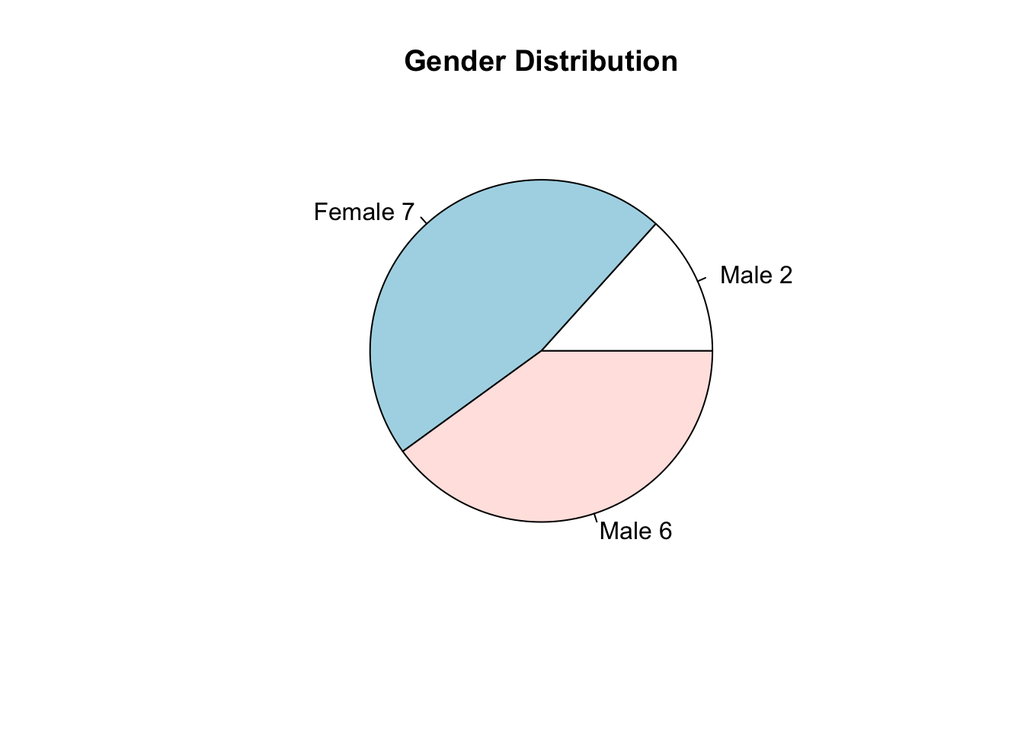

```r
pie(gender_count,
    main = "Gender Distribution",
    labels = paste(names(gender_count), gender_count))
```

### Interpretation

The pie chart shows the number of students belonging to each gender category. It provides a simple visual representation of the composition of the dataset.

# 9. Examination Result Distribution

The number of students in each result category is calculated.

```r
result_count <- table(student_data$Result)
result_count
```

```
##
## Fail Pass
##    3   12
```

The result distribution is displayed using a pie chart.

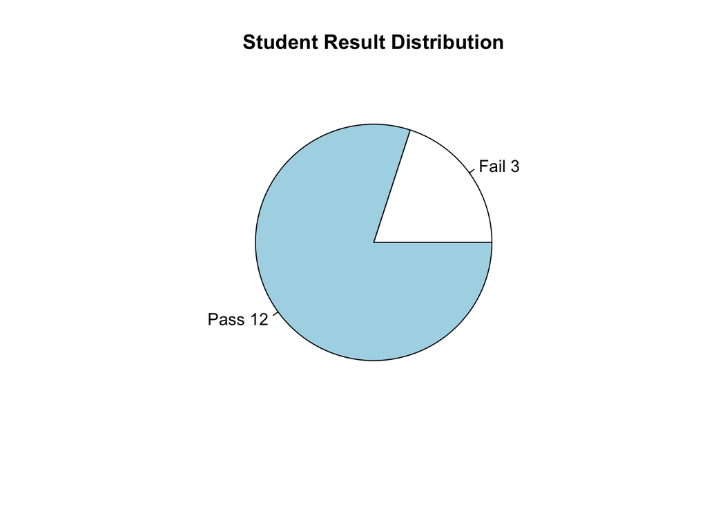

```r
pie(result_count,
    main = "Student Result Distribution",
    labels = paste(names(result_count), result_count))
```

### Interpretation

The chart shows how many students passed and failed. A higher number of successful students indicates better overall examination performance.

# 10. Student Marks Visualization

A bar plot is created to compare individual student marks.

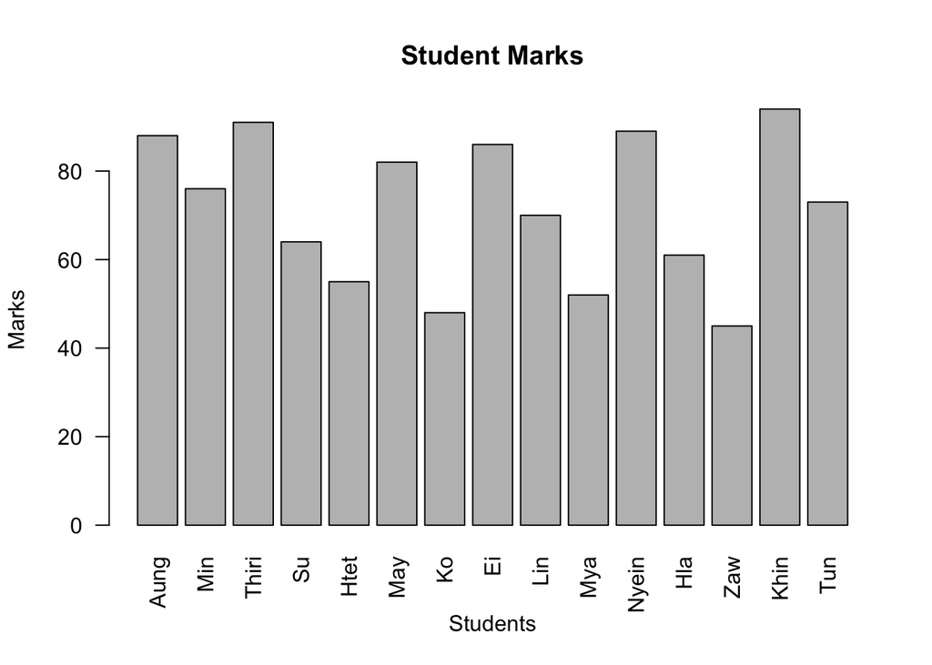

```r
barplot(student_data$Marks,
        names.arg = student_data$Name,
        main = "Student Marks",
        xlab = "Students",
        ylab = "Marks",
        las = 2)
```

### Interpretation

The bar chart allows individual marks to be compared. Taller bars represent students with higher marks, while shorter bars represent lower marks.

# 11. Attendance Visualization

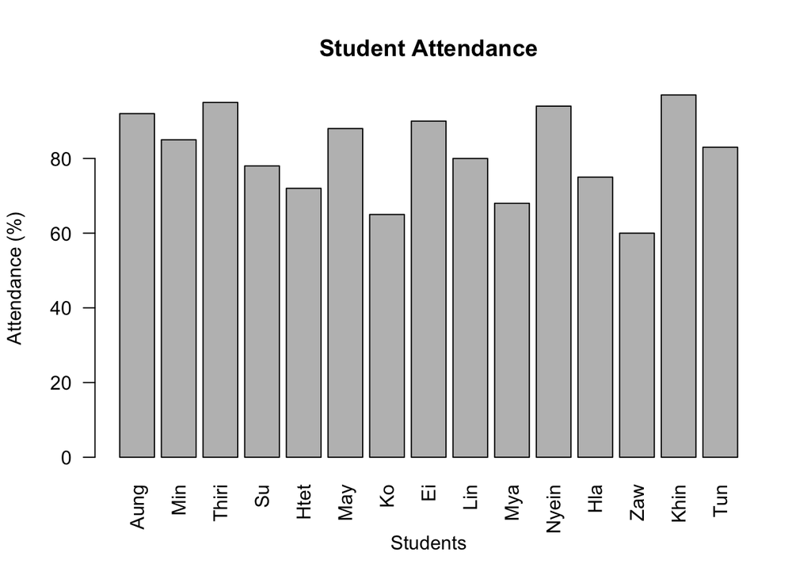

```r
barplot(student_data$Attendance,
        names.arg = student_data$Name,
        main = "Student Attendance",
        xlab = "Students",
        ylab = "Attendance (%)",
        las = 2)
```

### Interpretation

The attendance chart compares attendance percentages among students. It helps identify students with relatively high or low attendance.

# 12. Attendance and Marks Relationship

Correlation measures the strength and direction of the linear relationship between attendance and marks.

```r
correlation_value <- cor(student_data$Attendance,
                         student_data$Marks)

correlation_value
```

```
## [1] 0.9942616
```

A scatter plot is used to visualize the relationship.

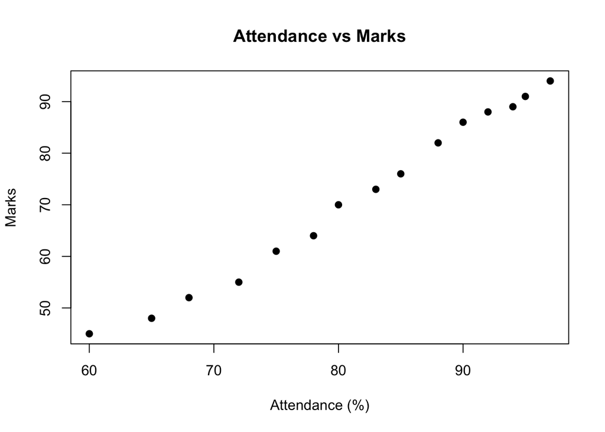

```r
plot(student_data$Attendance,
     student_data$Marks,
     main = "Attendance vs Marks",
     xlab = "Attendance (%)",
     ylab = "Marks",
     pch = 19)
```

### Interpretation

The correlation value indicates whether attendance and marks tend to increase or decrease together. A positive correlation suggests that students with higher attendance tend to have higher marks, while a negative correlation suggests the opposite. A value close to zero indicates a weak linear relationship.

The scatter plot provides a visual view of this relationship.

# 13. Additional Analysis: Average Marks by Gender

Average marks are calculated separately for each gender.

```r
aggregate(Marks ~ Gender,
          data = student_data,
          FUN = mean)
```

```
##   Gender    Marks
## 1   Male 82.00000
## 2 Female 75.71429
## 3   Male 63.33333
```

### Interpretation

This analysis compares the average academic performance of students across gender categories. The result should be interpreted as a description of this dataset only and not as a general conclusion about gender and academic ability.

# 14. Findings

Based on the analysis, the following aspects of student performance can be identified:

1. The average and median marks describe the overall academic level of the students.
2. Variance and standard deviation show the amount of variation in marks.
3. The gender frequency table and pie chart show the composition of the dataset.
4. The result distribution shows the number of successful and unsuccessful students.
5. The marks and attendance bar charts allow student-level comparison.
6. The correlation and scatter plot show the relationship between attendance and marks.
7. Average marks by gender provide an additional descriptive comparison.

# 15. Conclusion

This project demonstrates how R can be used for a complete basic data-analysis workflow. The CSV dataset was imported into R, inspected, checked for missing and duplicate values, and prepared for analysis. Descriptive statistics were calculated to understand marks and attendance. Pie charts and bar plots were used to visualize categorical and numerical information, while a scatter plot and correlation were used to study the relationship between attendance and marks.

R Markdown makes it possible to combine R code, output, graphs, explanations, and conclusions in one reproducible report. Therefore, it is useful for presenting data-analysis projects in a clear and organized format.

# 16. R Functions Used

| Function | Purpose |
| --- | --- |
| `read.csv()` | Imports CSV data |
| `head()` | Displays the first observations |
| `str()` | Displays data structure |
| `summary()` | Produces summary statistics |
| `is.na()` | Checks missing values |
| `duplicated()` | Checks duplicate rows |
| `mean()` | Calculates the mean |
| `median()` | Calculates the median |
| `var()` | Calculates variance |
| `sd()` | Calculates standard deviation |
| `table()` | Creates frequency tables |
| `pie()` | Creates pie charts |
| `barplot()` | Creates bar charts |
| `cor()` | Calculates correlation |
| `plot()` | Creates scatter plots |
| `aggregate()` | Calculates grouped summaries |